# Primera sesión de laboratorio

08/02/2015

## Tratamiento 1

- Una única empresa sirve el mercado de un producto.
- Cada unidad vendida tiene un coste unitario de \(200\ €\).
- La empresa elige a qué precio vende cada unidad de su producto.
- Los consumidores deciden cuántas unidades compran a ese precio.

## Ingresos

- La curva de demanda de la empresa es: \[ Q(P) = 1000 - 2 P \]
- Podemos escribir los ingresos totales como: \[ I = P Q(P) = 1000 P - 2 P^2 \]

## Costes

- El coste unitario es independiente de la producción: \[ CMe(Q) = 200 \]
- El coste total es: \[ C(Q) = 200 Q \]
- Podemos expresar los costes en función de los precios sustituyendo en la expresión anterior la función de demanda: \[ C = 200 Q(P) = 200000 - 400 P \]

## Beneficios

- Obtenemos los beneficios como diferencia de ingresos y costes: \[ \pi = I - C \]
- En nuestro caso: \[ \pi = 1000 P - 2 P^2 - (200000 - 400 P) \]
- Operando en la expresión anterior: \[ \pi = - 200000 + 1400 P - 2 P^2 \]

## Elección del precio

- Si la empresa maximiza beneficios, fijará un precio \(P^*\) de forma que: \[ \frac{\mathrm{d}\; \pi(P^*)}{\mathrm{d}\; P} = 0 \]
- La derivada de \(\pi\) con respecto al precio es: \[ \frac{\mathrm{d}\; \pi(P)}{\mathrm{d}\; P} = 1400 - 4 P \]
- Por tanto \[ P^* = 350\ \text{€/u.}; \quad Q^* = 300\ \text{u.}; \quad \pi^* = 45000\ \text{€}. \]

## Resultados del laboratorio

- Sesiones del 2 de febrero (grupo F) y 3 de febrero (grupo A) de 2015.
- Cada tratamiento estaba compuesto por 7 periodos.
- Número de sujetos: `79`

## Estadísticos descriptivos

| Period | Mean | SD | Min. | 25% | Median | 75% | Max. |
| --- | --- | --- | --- | --- | --- | --- | --- |
| 1 | 375.3 | 76.7 | 205 | 320 | 375 | 400 | 500 |
| 2 | 359.0 | 55.0 | 230 | 325 | 350 | 390 | 500 |
| 3 | 348.7 | 45.0 | 230 | 325 | 350 | 375 | 500 |
| 4 | 345.3 | 30.8 | 250 | 330 | 350 | 365 | 402 |
| 5 | 353.0 | 31.2 | 300 | 340 | 350 | 360 | 500 |
| 6 | 348.9 | 28.1 | 250 | 345 | 350 | 355 | 500 |
| 7 | 352.6 | 34.2 | 201 | 350 | 350 | 352 | 500 |

## Distribución de los precios

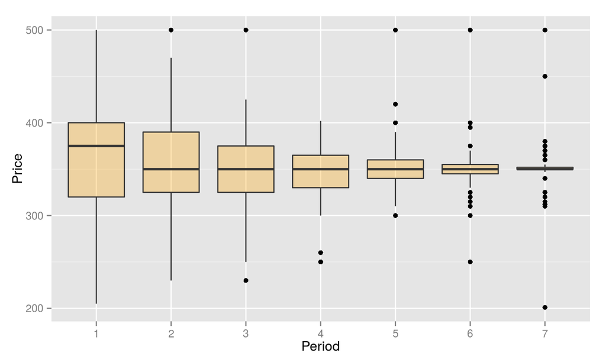

## Distribución de los precios

### Primer periodo

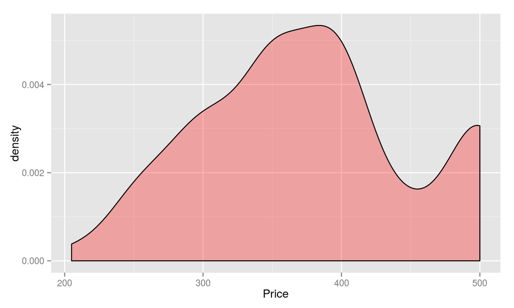

## Distribución de los precios

### Último periodo

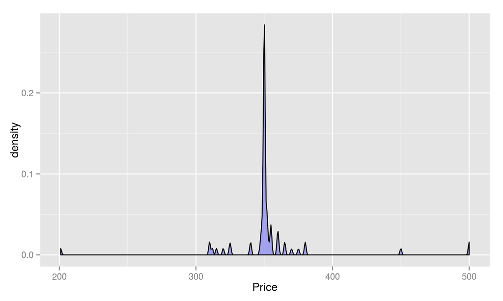

## Distribución de los precios

### Primer y último periodo

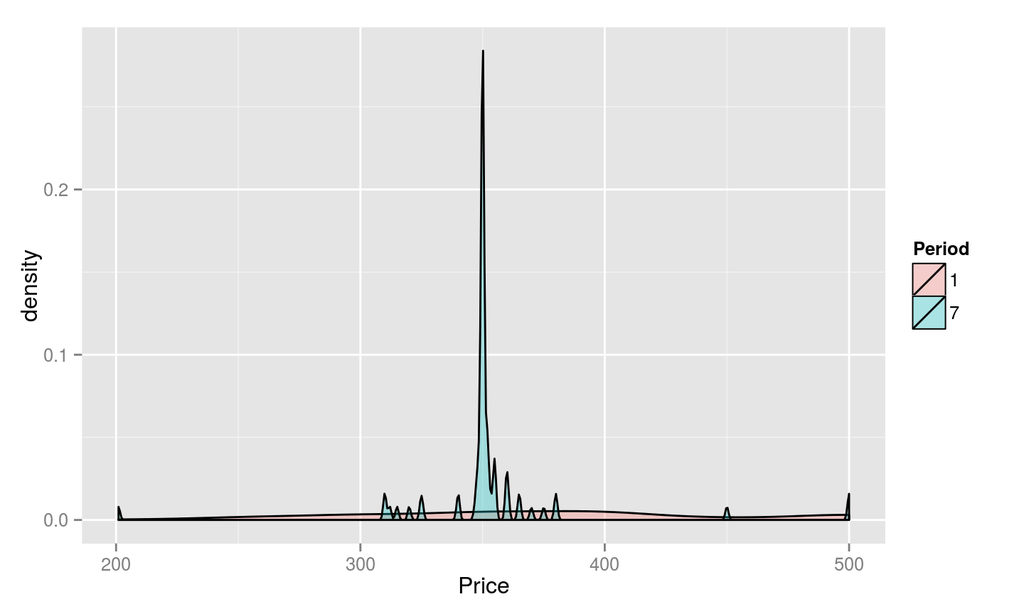

## Tratamiento 2

- Una única empresa sirve el mercado de un producto.
- Cada unidad vendida tiene un coste unitario de \(200\ €\).
- La empresa selecciona la cantidad que produce.
- La demanda determina el precio al que se vende cada unidad.

## Ingresos

- Curva (inversa) de demanda de la empresa: \[ P = 500 - \frac{1}{2} Q \]
- Ingreso total: \[ I(Q) = P(Q) Q = 500 Q - \frac{1}{2} Q^2 \]
- Ingreso marginal: \[ IMg(Q) = 500 - Q \]

## Costes

- El coste unitario es independiente de la producción: \[ CMe(Q) = 200 \]
- El coste total es: \[ C(Q) = 200 Q \]
- El coste marginal coincide con el coste unitario: \[ CMg(Q) = \frac{\mathrm{d}\; C(Q)}{\mathrm{d}\; Q} = 200 \]

## Elección del nivel de producción

- Condición de primer orden para la maximización del beneficio: \[ IMg(Q^*) = CMg(Q^*) \]
- En nuestro caso: \[ IMg(Q^*) = 500 - Q^* = 200 = CMg(Q^*) \]
- Por tanto \[ Q^* = 300\ \text{u.}; \quad P^* = 350\ \text{€/u.}; \quad \pi^* = 45000\ \text{€}. \]

## Estadísticos descriptivos

| Period | Mean | SD | Min. | 25% | Median | 75% | Max. |
| --- | --- | --- | --- | --- | --- | --- | --- |
| 1 | 274.0 | 80.8 | 20 | 250.0 | 300 | 315.0 | 450 |
| 2 | 305.8 | 77.1 | 10 | 277.5 | 300 | 350.0 | 500 |
| 3 | 309.6 | 80.0 | 0 | 300.0 | 320 | 350.0 | 500 |
| 4 | 306.4 | 64.9 | 0 | 297.0 | 301 | 343.0 | 450 |
| 5 | 291.1 | 65.2 | 1 | 292.5 | 300 | 310.0 | 400 |
| 6 | 294.6 | 62.9 | 0 | 298.5 | 300 | 307.5 | 500 |
| 7 | 301.2 | 60.4 | 10 | 300.0 | 300 | 309.5 | 499 |

## Distribución de las cantidades

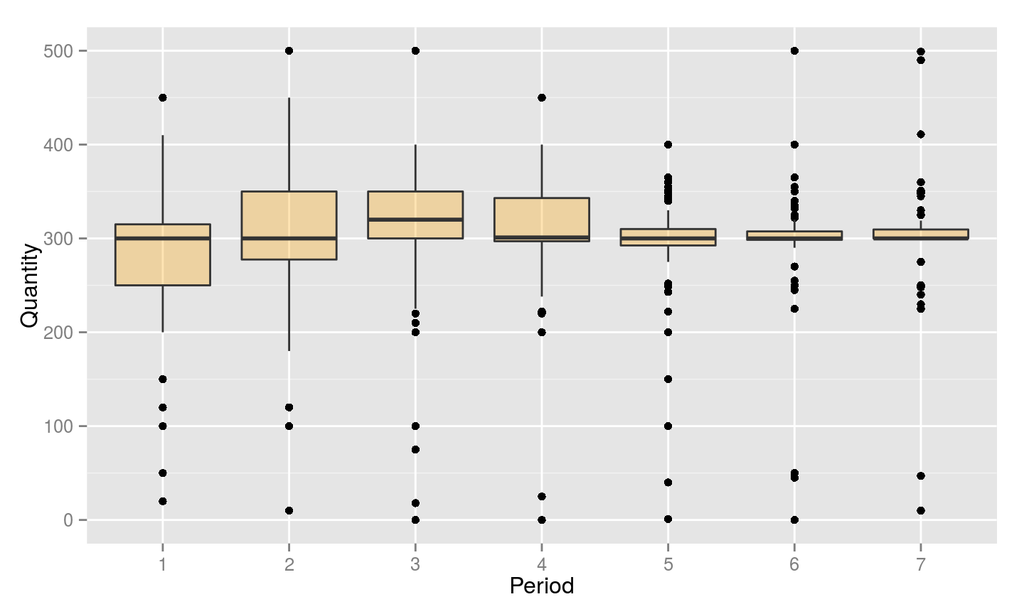

## Distribución de las cantidades

### Primer periodo

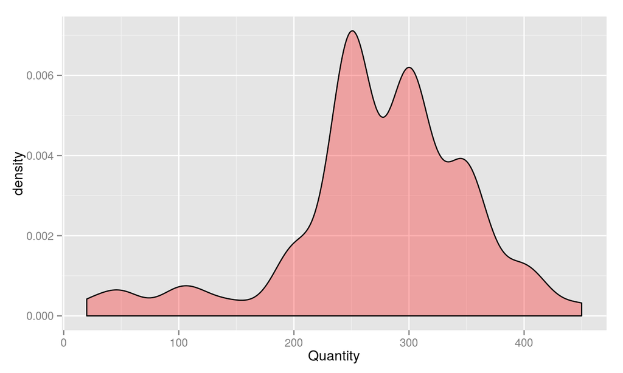

## Distribución de las cantidades

### Último periodo

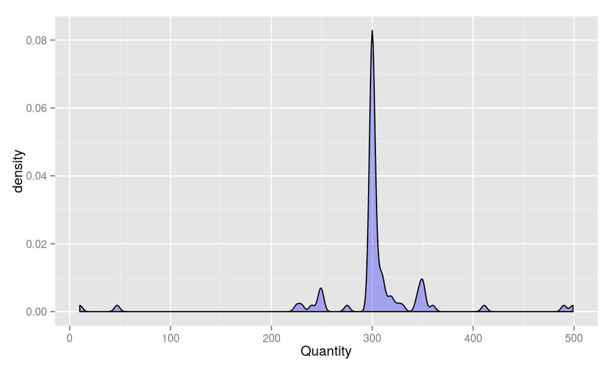

## Distribución de las cantidades

### Primer y último periodo

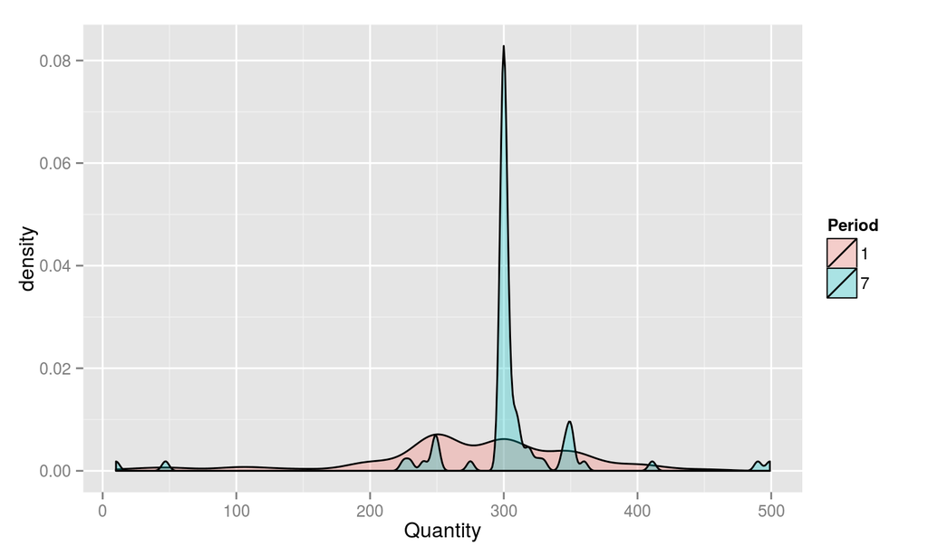